# Hausaufgabe Sitzung 3, Bissantz, Wintersemster 20/21

```r
library(tidyverse)
library(arules)
library(arulesViz)
```

```r
all <- read_delim("all.csv",
    ",", escape_double = FALSE, trim_ws = TRUE)
```

```
1105 parsing failures.
 row                 col  expected                                            actual      file
3564 Year-Of-Publication a double  Tom Milne                                         'all.csv'
3564 Age                 a double  canberra, australian capital territory, australia 'all.csv'
3564 NA                  9 columns 10 columns                                        'all.csv'
4012 Year-Of-Publication a double  William Goldman                                   'all.csv'
4012 NA                  9 columns 10 columns                                        'all.csv'
.... ................... ......... ................................................. .........
See problems(...) for more details.
```

# Aufgabe: Erstellen Sie eine Analyse, bei der nicht die Bücher, sondern die AutorInnen in den Transaktionen enthalten sind

## Mit splitt () werden die Variablen Book-Author und User-ID aus dem Dataframe all in i neu zusammengesetzt. In apriori () werden Werte wie Support und Confidence händisch festgelegt, mit denen dann gefiltert werden kann, ab welcher Stärke der Verbindungen Informationen ausgeworfen werden.

```r
i <- split(all$`Book-Author`,all$`User-ID`)
txn <- as(i, "transactions")
```

```
removing duplicated items in transactions
```

```r
basket_rules <- apriori(txn, parameter = list(sup = 0.0060, conf = 0.001, minlen=2, target="rules"))
```

```
Apriori

Parameter specification:
```

|  | confidence | minval | smax | arem | aval | originalSupport | maxtime | support | minlen | maxlen | target | ext |
| --- | --- | --- | --- | --- | --- | --- | --- | --- | --- | --- | --- | --- |
|  | 0.001 | 0.1 | 1 | none | FALSE | TRUE | 5 | 0.006 | 2 | 10 | rules | TRUE |

```
Algorithmic control:
```

|  | filter | tree | heap | memopt | load | sort | verbose |
| --- | --- | --- | --- | --- | --- | --- | --- |
|  | 0.1 | TRUE | TRUE | FALSE | TRUE | 2 | TRUE |

```
Absolute minimum support count: 552

set item appearances ...[0 item(s)] done [0.03s].
set transactions ...[101708 item(s), 92107 transaction(s)] done [1.94s].
sorting and recoding items ... [140 item(s)] done [0.08s].
creating transaction tree ... done [0.08s].
checking subsets of size 1 2 3 done [0.08s].
writing ... [56 rule(s)] done [0.04s].
creating S4 object  ... done [0.12s].
```

```r
myRules_Direct <- as(basket_rules, "data.frame")
basket_rules_hi <- head(basket_rules, by ="lift",100)
head(myRules_Direct, 20)
```

|  | rules | support | confidence | coverage | lift | count |
| --- | --- | --- | --- | --- | --- | --- |
| 1 | {Patricia Daniels Cornwell} => {James Patterson} | 0.006221026 | 0.3921971 | 0.01586199 | 12.635222 | 573 |
| 2 | {James Patterson} => {Patricia Daniels Cornwell} | 0.006221026 | 0.2004197 | 0.03103999 | 12.635222 | 573 |
| 3 | {Patricia Daniels Cornwell} => {John Grisham} | 0.006177598 | 0.3894593 | 0.01586199 | 9.925823 | 569 |
| 4 | {John Grisham} => {Patricia Daniels Cornwell} | 0.006177598 | 0.1574433 | 0.03923697 | 9.925823 | 569 |
| 5 | {Anne Rice} => {Stephen King} | 0.007404432 | 0.4128329 | 0.01793566 | 9.539589 | 682 |
| 6 | {Stephen King} => {Anne Rice} | 0.007404432 | 0.1710988 | 0.04327576 | 9.539589 | 682 |
| 7 | {Nicholas Sparks} => {James Patterson} | 0.006069028 | 0.3117680 | 0.01946649 | 10.044076 | 559 |
| 8 | {James Patterson} => {Nicholas Sparks} | 0.006069028 | 0.1955229 | 0.03103999 | 10.044076 | 559 |
| 9 | {Nicholas Sparks} => {John Grisham} | 0.006427307 | 0.3301729 | 0.01946649 | 8.414841 | 592 |
| 10 | {John Grisham} => {Nicholas Sparks} | 0.006427307 | 0.1638074 | 0.03923697 | 8.414841 | 592 |

[output cut: 10 more lines]

## Mit plot() werden die Verbindungen zwischen den AutorInnen graphisch dargestellt. Die roten Kreise geben die Stärke der Verbindung an.

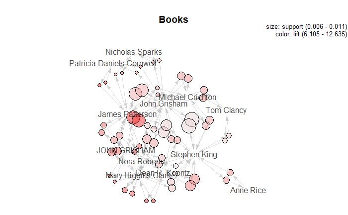

```r
plot(basket_rules_hi, method="graph", main="Books")
```

## Hier werden durch engine=“interactive” eine interaktive Oberfläche gebildet und die AutorInnen können lesbar und in Gruppen positioniert werden.

```r
plot(basket_rules_hi, method="graph", main="Books", engine="interactive")
```

## Beim Arbeiten mit den Plots und verschiedenen Einstellungen von Support-Werten lässt sich die schwere Balance sehen zwischen “zu wenig Informationen” und “zu viele Informationen”. Letzlich habe ich mich für einen Verhältnismäßig hohen Support-Wert entschieden, bei dem Verbindungen für mich im Plot deutlicher nachzuvollziehen waren. Hier sieht man allerdings vor allem die “populären” AutorInnen, wie zum Beispiel Stephen King. Stephen King oder auch John Grisham werden viel gelesen und lassen sich nach diesem Plot allgemein LeserInnen empfehlen. Feinere Verbindungen zwischen Nischen-AutorInnen bleiben hier jedoch außen vor.

# Aufgabe: Fällt Ihnen etwas in der Datenqualität auf?

## Ein größeres Problem bildet eine nicht normierte Schreibweise der Namen von AutorInnen - insondere die Groß- und Kleinschreibung und Sonderzeichen.

# Aufgabe: Wie könnte man das mit regulären Ausdrücken beheben?

## Mit dem Befehl tolower() können AutorInnen einheitlich klein geschrieben werden. Mit str_replace_all() können Sonderzeichen aus den Namen entfernt werden.

# Aufgabe: Wie kann man nun noch sicherstellen, dass nur die AutorInnen weiterempfohlen werden, deren Bücher man auch (mehrheitlich) gut fand?

## Mit dem Befehl filter() können wir die Bewertungen auf höhere Werte reduzieren und kriegen so nur Verlinkungen von als “gut” befunden AutorInnen.

# Aufgabe: Welche anderen Features wären sinnvoll?

## Andere Variablen mit einzubeziehen (Location oder Age von Usern) könnten sehr aufschlussreich sein. Frage wäre nur, wie das gut in den vorliegenden Plots dargestellt werden könnte. Es könnten einzelne Dataframes gebaut werden, innerhalb diesen dann nach Location oder Age gefiltert werden würde. Ein interessantes Feauture wäre die einzelnen AutorInnen gruppieren zu können: nach Genre, Geschlecht, Zeit in der sie gewirkt haben, oder bestimmte Themen, mit denen sie sich befasst haben… Informationen wie diese könnten in Kombination mit LeserInnenpräferenzen hilfreich sein.